# Augmented Dynamic Adaptive Model

Ivan Svetunkov

2026-09-04

This vignette explains briefly how to use the function `adam()` and the related `auto.adam()` in `smooth` package. It does not aim at covering all aspects of the function, but focuses on the main ones.

ADAM is Augmented Dynamic Adaptive Model. It is a model that underlies ETS, ARIMA and regression, connecting them in a unified framework. The underlying model for ADAM is a Single Source of Error state space model, which is explained in detail separately in an [online monograph](https://openforecast.org/adam/).

The main philosophy of `adam()` function is to be agnostic of the provided data. This means that it will work with `ts`, `msts`, `zoo`, `xts`, `data.frame`, `numeric` and other classes of data. The specification of seasonality in the model is done using a separate parameter `lags`, so you are not obliged to transform the existing data to something specific, and can use it as is. If you provide a `matrix`, or a `data.frame`, or a `data.table`, or any other multivariate structure, then the function will use the first column for the response variable and the others for the explanatory ones. One thing that is currently assumed in the function is that the data is measured at a regular frequency. If this is not the case, you will need to introduce missing values manually.

In order to run the experiments in this vignette, we need to load the following packages:

```r
require(greybox)
require(smooth)
```

## ADAM ETS

```r
testModel <- adam(AirPassengers, "MMM", lags=c(1,12), distribution="dnorm",
                  h=12, holdout=TRUE)
summary(testModel)
```

```
#>
#> Model estimated using adam() function: ETS(MMM)
#> Response variable: AirPassengers
#> Distribution used in the estimation: Normal
#> Loss function type: likelihood; Loss function value: 465.9969
#> Coefficients:
#>       Estimate Std. Error Lower 2.5% Upper 97.5%
#> alpha   0.7565     0.0947     0.5688      0.9437 *
#> beta    0.0004     0.0191     0.0000      0.0382
#> gamma   0.0000     0.0522     0.0000      0.1032
#>
#> Error standard deviation: 0.0365
#> Sample size: 132
#> Number of estimated parameters: 17
#> Number of degrees of freedom: 115
#> Information criteria:
#>       AIC      AICc       BIC      BICc
#>  965.9937  971.3621 1015.0013 1028.1078
```

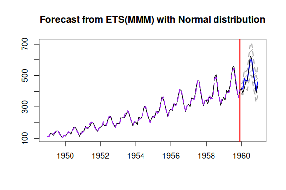

```r
plot(forecast(testModel,h=12,interval="prediction"))
```

You might notice that the summary contains more than what is reported by other `smooth` functions. This one also produces standard errors for the estimated parameters based on Fisher Information calculation. Note that this is computationally expensive, so if you have a model with more than 30 variables, the calculation of standard errors might take plenty of time. As for the default `print()` method, it will produce a shorter summary from the model, without the standard errors (similar to what `es()` does):

```r
testModel
```

```
#> Time elapsed: 0.07 seconds
#> Model estimated using adam() function: ETS(MMM)
#> With backcasting initialisation
#> Distribution assumed in the model: Normal
#> Loss function type: likelihood; Loss function value: 465.9969
#> Persistence vector g:
#>  alpha   beta  gamma
#> 0.7565 0.0004 0.0000
#>
#> Sample size: 132
#> Number of estimated parameters: 17
#> Number of degrees of freedom: 115
#> Information criteria:
#>       AIC      AICc       BIC      BICc
#>  965.9937  971.3621 1015.0013 1028.1078
#>
#> Forecast errors:
#> ME: -9.668; MAE: 15.499; RMSE: 22.94
#> sCE: -44.196%; Asymmetry: -59.4%; sMAE: 5.904%; sMSE: 0.764%
#> MASE: 0.644; RMSSE: 0.732; rMAE: 0.204; rRMSE: 0.223
```

Also, note that the prediction interval in case of multiplicative error models are approximate. It is advisable to use simulations instead (which is slower, but more accurate):

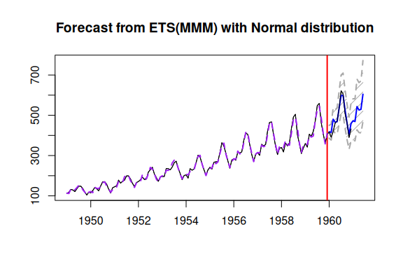

```r
plot(forecast(testModel,h=18,interval="simulated"))
```

If you want to do the residuals diagnostics, then it is recommended to use `plot` function, something like this (you can select, which of the plots to produce):

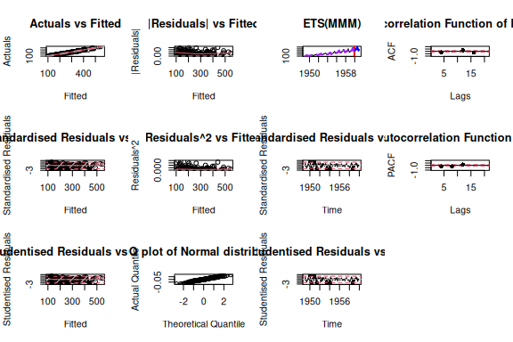

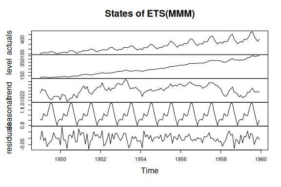

```r
par(mfcol=c(3,4))
plot(testModel,which=c(1:11))
par(mfcol=c(1,1))
plot(testModel,which=12)
```

By default ADAM will estimate models via maximising likelihood function. But there is also a parameter `loss`, which allows selecting from a list of already implemented loss functions (again, see documentation for `adam()` for the full list) or using a function written by a user. Here is how to do the latter on the example of `BJsales`:

```r
lossFunction <- function(actual, fitted, B){
  return(sum(abs(actual-fitted)^3))
}
testModel <- adam(BJsales, "AAN", silent=FALSE, loss=lossFunction,
                  h=12, holdout=TRUE)
testModel
```

```
#> Time elapsed: 0.02 seconds
#> Model estimated using adam() function: ETS(AAN)
#> With backcasting initialisation
#> Distribution assumed in the model: Normal
#> Loss function type: custom; Loss function value: 599.3072
#> Persistence vector g:
#> alpha  beta
#> 1.000 0.227
#>
#> Sample size: 138
#> Number of estimated parameters: 5
#> Number of degrees of freedom: 133
#> Information criteria are unavailable for the chosen loss & distribution.
#>
#> Forecast errors:
#> ME: 3.015; MAE: 3.129; RMSE: 3.866
#> sCE: 15.916%; Asymmetry: 91.7%; sMAE: 1.376%; sMSE: 0.029%
#> MASE: 2.626; RMSSE: 2.52; rMAE: 1.009; rRMSE: 1.009
```

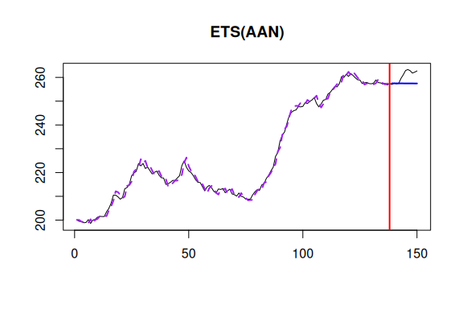

Note that you need to have parameters actual, fitted and B in the function, which correspond to the vector of actual values, vector of fitted values on each iteration and a vector of the optimised parameters.

`loss` and `distribution` parameters are independent, so in the example above, we have assumed that the error term follows Normal distribution, but we have estimated its parameters using a non-conventional loss because we can. Some of distributions assume that there is an additional parameter, which can either be estimated or provided by user. These include Asymmetric Laplace (`distribution="dalaplace"`) with `alpha`, Generalised Normal and Log-Generalised normal (`distribution=c("gnorm","dlgnorm")`) with `shape` and Student’s T (`distribution="dt"`) with `nu`:

```r
testModel <- adam(BJsales, "MMN", silent=FALSE, distribution="dgnorm", shape=3,
                  h=12, holdout=TRUE)
```

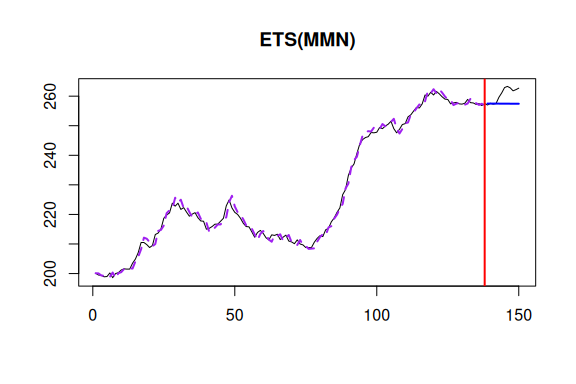

The model selection in ADAM ETS relies on information criteria and works correctly only for the `loss="likelihood"`. There are several options, how to select the model, see them in the description of the function: `?adam()`. The default one uses branch-and-bound algorithm, similar to the one used in `es()`, but only considers additive trend models (the multiplicative trend ones are less stable and need more attention from a forecaster):

```r
testModel <- adam(AirPassengers, "ZXZ", lags=c(1,12), silent=FALSE,
                  h=12, holdout=TRUE)
```

```
#> Forming the pool of models based on... ANN , ANA , MNM , MAM , Estimation progress:    71 %86 %100 %... Done!
```

```r
testModel
```

```
#> Time elapsed: 0.19 seconds
#> Model estimated using adam() function: ETS(MAM)
#> With backcasting initialisation
#> Distribution assumed in the model: Gamma
#> Loss function type: likelihood; Loss function value: 467.1158
#> Persistence vector g:
#>  alpha   beta  gamma
#> 0.7918 0.0000 0.0000
#>
#> Sample size: 132
#> Number of estimated parameters: 17
#> Number of degrees of freedom: 115
#> Information criteria:
#>       AIC      AICc       BIC      BICc
#>  968.2316  973.6000 1017.2392 1030.3457
#>
#> Forecast errors:
#> ME: 5.66; MAE: 18.165; RMSE: 24.481
#> sCE: 25.873%; Asymmetry: 52.1%; sMAE: 6.92%; sMSE: 0.87%
#> MASE: 0.754; RMSSE: 0.781; rMAE: 0.239; rRMSE: 0.238
```

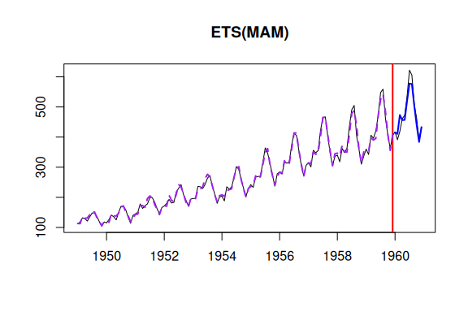

Note that the function produces point forecasts if `h>0`, but it won’t generate prediction interval. This is why you need to use `forecast()` method (as shown in the first example in this vignette).

Similarly to `es()`, function supports combination of models, but it saves all the tested models in the output for a potential reuse. Here how it works:

```r
testModel <- adam(AirPassengers, "CXC", lags=c(1,12),
                  h=12, holdout=TRUE)
testForecast <- forecast(testModel,h=18,interval="semiparametric", level=c(0.9,0.95))
testForecast
```

```
#>          Point forecast Lower bound (5%) Lower bound (2.5%) Upper bound (95%)
#> Jan 1960       415.4685         404.8871           402.8871          426.1644
#> Feb 1960       410.5197         385.7838           381.1962          435.8987
#> Mar 1960       473.1934         437.7221           431.1977          509.8194
#> Apr 1960       456.2041         415.7704           408.3911          498.2037
#> May 1960       456.8834         413.1037           405.1469          502.5023
#> Jun 1960       519.2702         468.4705           459.2486          572.2509
#> Jul 1960       577.2239         518.7139           508.1142          638.3410
#> Aug 1960       576.2441         516.5081           505.7010          638.7051
#> Sep 1960       503.1352         450.1200           440.5383          558.6106
#> Oct 1960       439.2604         392.6588           384.2399          488.0402
#> Nov 1960       383.5831         342.5207           335.1067          426.5829
#> Dec 1960       432.9058         386.4716           378.0887          481.5357
#> Jan 1961       443.4274         395.1921           386.4919          493.9774
#> Feb 1961       437.9914         389.1927           380.4046          489.1913
#> Mar 1961       504.6827         445.2612           434.6001          567.2032
#> Apr 1961       486.3948         426.4645           415.7473          549.6042
#> May 1961       486.9525         425.0999           414.0643          552.3002
#> Jun 1961       553.2584         484.2566           471.9283          626.0844
#>          Upper bound (97.5%)
#> Jan 1960            428.2408
#> Feb 1960            440.9144
#> Mar 1960            517.1128
#> Apr 1960            506.6258
#> May 1960            511.6838
#> Jun 1960            582.9250
#> Jul 1960            650.6766
#> Aug 1960            651.3268
#> Sep 1960            569.8304
#> Oct 1960            497.9095
#> Nov 1960            435.2870
#> Dec 1960            491.3806
#> Jan 1961            504.2189
#> Feb 1961            499.5783
#> Mar 1961            579.9277
#> Apr 1961            562.5048
#> May 1961            565.6630
#> Jun 1961            640.9591
```

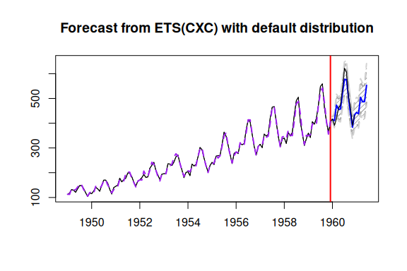

```r
plot(testForecast)
```

Yes, now we support vectors for the levels in case you want to produce several. In fact, we also support side for prediction interval, so you can extract specific quantiles without a hustle:

```r
forecast(testModel,h=18,interval="semiparametric", level=c(0.9,0.95,0.99), side="upper")
```

```
#>          Point forecast Upper bound (90%) Upper bound (95%) Upper bound (99%)
#> Jan 1960       415.4685          423.7789          426.1644          430.6634
#> Feb 1960       410.5197          430.1630          435.8987          446.7942
#> Mar 1960       473.1934          501.4956          509.8194          525.6793
#> Apr 1960       456.2041          488.6092          498.2037          516.5359
#> May 1960       456.8834          492.0526          502.5023          522.4978
#> Jun 1960       519.2702          560.1057          572.2509          595.5003
#> Jul 1960       577.2239          624.3119          638.3410          665.2160
#> Aug 1960       576.2441          624.3550          638.7051          666.2078
#> Sep 1960       503.1352          545.8572          558.6106          583.0616
#> Oct 1960       439.2604          476.8230          488.0402          509.5492
#> Nov 1960       383.5831          416.6913          426.5829          445.5538
#> Dec 1960       432.9058          470.3481          481.5357          502.9932
#> Jan 1961       443.4274          482.3413          493.9774          516.3018
#> Feb 1961       437.9914          477.3939          489.1913          511.8372
#> Mar 1961       504.6827          552.7630          567.2032          594.9576
#> Apr 1961       486.3948          534.9748          549.6042          577.7534
#> May 1961       486.9525          537.1542          552.3002          581.4657
#> Jun 1961       553.2584          609.2198          626.0844          658.5444
```

A brand new thing in the function is the possibility to use several frequencies (double / triple / quadruple / … seasonal models). In order to show how it works, we will generate an artificial time series, inspired by half-hourly electricity demand using `sim.gum()` function:

```r
set.seed(41)
ordersGUM <- c(1,1,1)
lagsGUM <- c(1,48,336)
initialGUM1 <- -25381.7
initialGUM2 <- c(23955.09, 24248.75, 24848.54, 25012.63, 24634.14, 24548.22, 24544.63, 24572.77,
                 24498.33, 24250.94, 24545.44, 25005.92, 26164.65, 27038.55, 28262.16, 28619.83,
                 28892.19, 28575.07, 28837.87, 28695.12, 28623.02, 28679.42, 28682.16, 28683.40,
                 28647.97, 28374.42, 28261.56, 28199.69, 28341.69, 28314.12, 28252.46, 28491.20,
                 28647.98, 28761.28, 28560.11, 28059.95, 27719.22, 27530.23, 27315.47, 27028.83,
                 26933.75, 26961.91, 27372.44, 27362.18, 27271.31, 26365.97, 25570.88, 25058.01)
initialGUM3 <- c(23920.16, 23026.43, 22812.23, 23169.52, 23332.56, 23129.27, 22941.20, 22692.40,
                 22607.53, 22427.79, 22227.64, 22580.72, 23871.99, 25758.34, 28092.21, 30220.46,
                 31786.51, 32699.80, 33225.72, 33788.82, 33892.25, 34112.97, 34231.06, 34449.53,
                 34423.61, 34333.93, 34085.28, 33948.46, 33791.81, 33736.17, 33536.61, 33633.48,
                 33798.09, 33918.13, 33871.41, 33403.75, 32706.46, 31929.96, 31400.48, 30798.24,
                 29958.04, 30020.36, 29822.62, 30414.88, 30100.74, 29833.49, 28302.29, 26906.72,
                 26378.64, 25382.11, 25108.30, 25407.07, 25469.06, 25291.89, 25054.11, 24802.21,
                 24681.89, 24366.97, 24134.74, 24304.08, 25253.99, 26950.23, 29080.48, 31076.33,
                 32453.20, 33232.81, 33661.61, 33991.21, 34017.02, 34164.47, 34398.01, 34655.21,
                 34746.83, 34596.60, 34396.54, 34236.31, 34153.32, 34102.62, 33970.92, 34016.13,
                 34237.27, 34430.08, 34379.39, 33944.06, 33154.67, 32418.62, 31781.90, 31208.69,
                 30662.59, 30230.67, 30062.80, 30421.11, 30710.54, 30239.27, 28949.56, 27506.96,
                 26891.75, 25946.24, 25599.88, 25921.47, 26023.51, 25826.29, 25548.72, 25405.78,
                 25210.45, 25046.38, 24759.76, 24957.54, 25815.10, 27568.98, 29765.24, 31728.25,
                 32987.51, 33633.74, 34021.09, 34407.19, 34464.65, 34540.67, 34644.56, 34756.59,
                 34743.81, 34630.05, 34506.39, 34319.61, 34110.96, 33961.19, 33876.04, 33969.95,
                 34220.96, 34444.66, 34474.57, 34018.83, 33307.40, 32718.90, 32115.27, 31663.53,
                 30903.82, 31013.83, 31025.04, 31106.81, 30681.74, 30245.70, 29055.49, 27582.68,
                 26974.67, 25993.83, 25701.93, 25940.87, 26098.63, 25771.85, 25468.41, 25315.74,
                 25131.87, 24913.15, 24641.53, 24807.15, 25760.85, 27386.39, 29570.03, 31634.00,
                 32911.26, 33603.94, 34020.90, 34297.65, 34308.37, 34504.71, 34586.78, 34725.81,
                 34765.47, 34619.92, 34478.54, 34285.00, 34071.90, 33986.48, 33756.85, 33799.37,
                 33987.95, 34047.32, 33924.48, 33580.82, 32905.87, 32293.86, 31670.02, 31092.57,
                 30639.73, 30245.42, 30281.61, 30484.33, 30349.51, 29889.23, 28570.31, 27185.55,
                 26521.85, 25543.84, 25187.82, 25371.59, 25410.07, 25077.67, 24741.93, 24554.62,
                 24427.19, 24127.21, 23887.55, 24028.40, 24981.34, 26652.32, 28808.00, 30847.09,
                 32304.13, 33059.02, 33562.51, 33878.96, 33976.68, 34172.61, 34274.50, 34328.71,
                 34370.12, 34095.69, 33797.46, 33522.96, 33169.94, 32883.32, 32586.24, 32380.84,
                 32425.30, 32532.69, 32444.24, 32132.49, 31582.39, 30926.58, 30347.73, 29518.04,
                 29070.95, 28586.20, 28416.94, 28598.76, 28529.75, 28424.68, 27588.76, 26604.13,
                 26101.63, 25003.82, 24576.66, 24634.66, 24586.21, 24224.92, 23858.42, 23577.32,
                 23272.28, 22772.00, 22215.13, 21987.29, 21948.95, 22310.79, 22853.79, 24226.06,
                 25772.55, 27266.27, 28045.65, 28606.14, 28793.51, 28755.83, 28613.74, 28376.47,
                 27900.76, 27682.75, 27089.10, 26481.80, 26062.94, 25717.46, 25500.27, 25171.05,
                 25223.12, 25634.63, 26306.31, 26822.46, 26787.57, 26571.18, 26405.21, 26148.41,
                 25704.47, 25473.10, 25265.97, 26006.94, 26408.68, 26592.04, 26224.64, 25407.27,
                 25090.35, 23930.21, 23534.13, 23585.75, 23556.93, 23230.25, 22880.24, 22525.52,
                 22236.71, 21715.08, 21051.17, 20689.40, 20099.18, 19939.71, 19722.69, 20421.58,
                 21542.03, 22962.69, 23848.69, 24958.84, 25938.72, 26316.56, 26742.61, 26990.79,
                 27116.94, 27168.78, 26464.41, 25703.23, 25103.56, 24891.27, 24715.27, 24436.51,
                 24327.31, 24473.02, 24893.89, 25304.13, 25591.77, 25653.00, 25897.55, 25859.32,
                 25918.32, 25984.63, 26232.01, 26810.86, 27209.70, 26863.50, 25734.54, 24456.96)
y <- sim.gum(orders=ordersGUM, lags=lagsGUM, nsim=1, frequency=336, obs=3360,
             measurement=rep(1,3), transition=diag(3), persistence=c(0.045,0.162,0.375),
             initial=rbind(initialGUM1,initialGUM2,initialGUM3))$data
```

We can then apply ADAM to this data:

```r
testModel <- adam(y, "MMdM", lags=c(1,48,336), initial="backcasting",
                  silent=FALSE, h=336, holdout=TRUE)
testModel
```

```
#> Time elapsed: 1.75 seconds
#> Model estimated using adam() function: ETS(MMdM)[48, 336]
#> With backcasting initialisation
#> Distribution assumed in the model: Gamma
#> Loss function type: likelihood; Loss function value: 19566.52
#> Persistence vector g:
#>  alpha   beta gamma1 gamma2
#> 0.0214 0.0000 0.1824 0.2656
#> Damping parameter: 0.9367
#> Sample size: 3024
#> Number of estimated parameters: 343
#> Number of degrees of freedom: 2681
#> Information criteria:
#>      AIC     AICc      BIC     BICc
#> 39819.04 39907.10 41881.96 42234.81
#>
#> Forecast errors:
#> ME: 68.548; MAE: 142.003; RMSE: 182.9
#> sCE: 75.993%; Asymmetry: 49.8%; sMAE: 0.469%; sMSE: 0.004%
#> MASE: 0.191; RMSSE: 0.178; rMAE: 0.022; rRMSE: 0.023
```

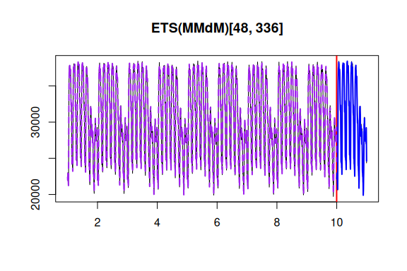

Note that the more lags you have, the more initial seasonal components the function will need to estimate, which is a difficult task. This is why we used `initial="backcasting"` in the example above - this speeds up the estimation by reducing the number of parameters to estimate. Still, the optimiser might not get close to the optimal value, so we can help it. First, we can give more time for the calculation, increasing the number of iterations via `maxeval` (the default value is 40 iterations for each estimated parameter, e.g. $40 \times 5 = 200$ in our case):

```r
testModel <- adam(y, "MMdM", lags=c(1,48,336), initial="backcasting",
                  silent=FALSE, h=336, holdout=TRUE, maxeval=10000)
testModel
```

```
#> Time elapsed: 1.84 seconds
#> Model estimated using adam() function: ETS(MMdM)[48, 336]
#> With backcasting initialisation
#> Distribution assumed in the model: Gamma
#> Loss function type: likelihood; Loss function value: 19566.52
#> Persistence vector g:
#>  alpha   beta gamma1 gamma2
#> 0.0214 0.0000 0.1824 0.2656
#> Damping parameter: 0.9367
#> Sample size: 3024
#> Number of estimated parameters: 343
#> Number of degrees of freedom: 2681
#> Information criteria:
#>      AIC     AICc      BIC     BICc
#> 39819.04 39907.10 41881.96 42234.81
#>
#> Forecast errors:
#> ME: 68.548; MAE: 142.003; RMSE: 182.9
#> sCE: 75.993%; Asymmetry: 49.8%; sMAE: 0.469%; sMSE: 0.004%
#> MASE: 0.191; RMSSE: 0.178; rMAE: 0.022; rRMSE: 0.023
```

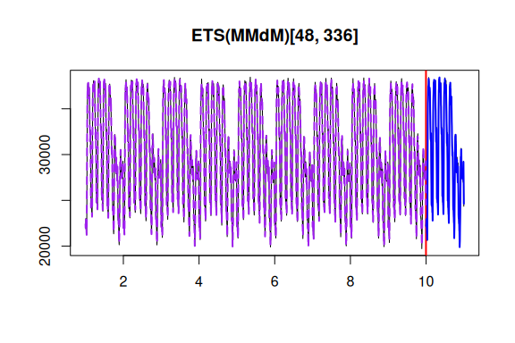

This will take more time, but will typically lead to more refined parameters. You can control other parameters of the optimiser as well, such as `algorithm`, `xtol_rel`, `print_level` and others, which are explained in the documentation for `nloptr` function from nloptr package (run `nloptr.print.options()` for details). Second, we can give a different set of initial parameters for the optimiser, have a look at what the function saves:

```r
testModel$B
```

and use this as a starting point for the reestimation (e.g. with a different algorithm):

```r
testModel <- adam(y, "MMdM", lags=c(1,48,336), initial="backcasting",
                  silent=FALSE, h=336, holdout=TRUE, B=testModel$B)
testModel
```

[output not shown]

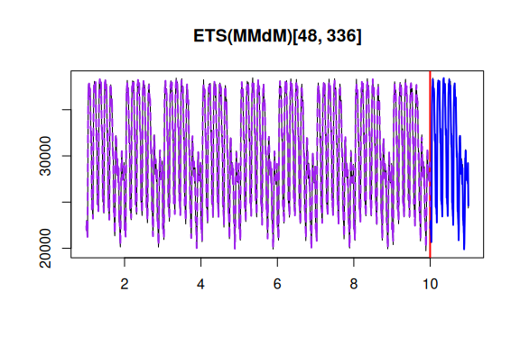

If you are ready to wait, you can change the initialisation to the `initial="optimal"`, which in our case will take much more time because of the number of estimated parameters - 389 for the chosen model. The estimation process in this case might take 20 - 30 times more than in the example above.

In addition, you can specify some parts of the initial state vector or some parts of the persistence vector, here is an example:

```r
testModel <- adam(y, "MMdM", lags=c(1,48,336), initial="backcasting",
                  silent=TRUE, h=336, holdout=TRUE, persistence=list(beta=0.1))
testModel
```

```
#> Time elapsed: 1.84 seconds
#> Model estimated using adam() function: ETS(MMdM)[48, 336]
#> With backcasting initialisation
#> Distribution assumed in the model: Gamma
#> Loss function type: likelihood; Loss function value: 51785.02
#> Persistence vector g:
#>  alpha   beta gamma1 gamma2
#> 0.1562 0.1000 0.3407 0.3811
#> Damping parameter: 0.9373
#> Sample size: 3024
#> Number of estimated parameters: 342
#> Number of degrees of freedom: 2682
#> Number of provided parameters: 1
#> Information criteria:
#>      AIC     AICc      BIC     BICc
#> 104254.0 104341.6 106310.9 106661.6
#>
#> Forecast errors:
#> ME: -4.29763056185173e+39; MAE: 4.29763056185173e+39; RMSE: 3.98231851127642e+40
#> sCE: -4.76438546244817e+39%; Asymmetry: -100%; sMAE: 1.41797186382386e+37%; sMSE: 1.72643031414497e+74%
#> MASE: 5.78735532915634e+36; RMSSE: 3.87290154968496e+37; rMAE: 6.71717311177841e+35; rRMSE: 5.05188885598057e+36
```

The function also handles intermittent data (the data with zeroes) and the data with missing values. This is partially covered in the vignette on the oes() function. Here is a simple example:

```r
testModel <- adam(rpois(120,0.5), "MNN", silent=FALSE, h=12, holdout=TRUE,
                  occurrence="odds-ratio")
testModel
```

[output not shown]

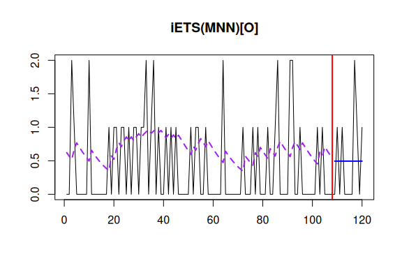

```r
adamModel <- adam(AirPassengers, "CCC",
                  h=12, holdout=TRUE)
esModel <- es(AirPassengers, "CCC",
              h=12, holdout=TRUE)
"adam:"
```

```
#> [1] "adam:"
```

```r
adamModel
```

```
#> Time elapsed: 0.96 seconds
#> Model estimated: ETS(CCC)
#> Loss function type: likelihood
#>
#> Number of models combined: 30
#> Sample size: 132
#> Average number of estimated parameters: 17.3766
#> Average number of degrees of freedom: 114.6234
#>
#> Forecast errors:
#> ME: 0.287; MAE: 15.724; RMSE: 22.507
#> sCE: 1.312%; sMAE: 5.99%; sMSE: 0.735%
#> MASE: 0.653; RMSSE: 0.718; rMAE: 0.207; rRMSE: 0.219
```

```r
"es():"
```

```
#> [1] "es():"
```

```r
esModel
```

```
#> Time elapsed: 0.9 seconds
#> Model estimated: ETS(CCC)
#> Loss function type: likelihood
#>
#> Number of models combined: 30
#> Sample size: 132
#> Average number of estimated parameters: 17.1346
#> Average number of degrees of freedom: 114.8654
#>
#> Forecast errors:
#> ME: -3.219; MAE: 15.414; RMSE: 22.026
#> sCE: -14.715%; sMAE: 5.872%; sMSE: 0.704%
#> MASE: 0.64; RMSSE: 0.703; rMAE: 0.203; rRMSE: 0.214
```

# ADAM ARIMA

As mentioned above, ADAM does not only contain ETS, it also contains ARIMA model, which is regulated via `orders` parameter. If you want to have a pure ARIMA, you need to switch off ETS, which is done via `model="NNN"`:

```r
testModel <- adam(BJsales, "NNN", silent=FALSE, orders=c(0,2,2),
                  h=12, holdout=TRUE)
testModel
```

```
#> Time elapsed: 0.02 seconds
#> Model estimated using adam() function: ARIMA(0,2,2)
#> With backcasting initialisation
#> Distribution assumed in the model: Normal
#> Loss function type: likelihood; Loss function value: 240.5973
#> ARMA parameters of the model:
#>         Lag 1
#> MA(1) -0.7488
#> MA(2) -0.0175
#>
#> Sample size: 138
#> Number of estimated parameters: 5
#> Number of degrees of freedom: 133
#> Information criteria:
#>      AIC     AICc      BIC     BICc
#> 491.1947 491.6492 505.8309 506.9508
#>
#> Forecast errors:
#> ME: 2.963; MAE: 3.089; RMSE: 3.815
#> sCE: 15.642%; Asymmetry: 90.2%; sMAE: 1.359%; sMSE: 0.028%
#> MASE: 2.593; RMSSE: 2.487; rMAE: 0.996; rRMSE: 0.996
```

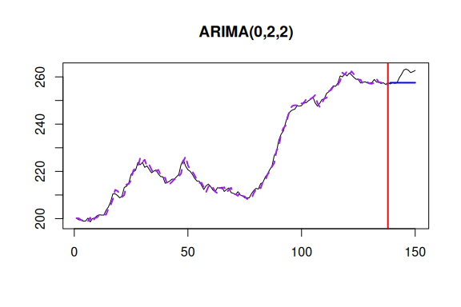

Given that both models are implemented in the same framework, they can be compared using information criteria.

The functionality of ADAM ARIMA is similar to the one of `msarima` function in `smooth` package, although there are several differences.

First, changing the `distribution` parameter will allow switching between additive / multiplicative models. For example, `distribution="dlnorm"` will create an ARIMA, equivalent to the one on logarithms of the data:

```r
testModel <- adam(AirPassengers, "NNN", silent=FALSE, lags=c(1,12),
                  orders=list(ar=c(1,1),i=c(1,1),ma=c(2,2)), distribution="dlnorm",
                  h=12, holdout=TRUE)
testModel
```

```
#> Time elapsed: 0.13 seconds
#> Model estimated using adam() function: SARIMA(1,1,2)[1](1,1,2)[12]
#> With backcasting initialisation
#> Distribution assumed in the model: Log-Normal
#> Loss function type: likelihood; Loss function value: 483.4464
#> ARMA parameters of the model:
#>         Lag 1  Lag 12
#> AR(1) -0.8424 -0.7557
#>         Lag 1 Lag 12
#> MA(1)  0.6089 0.7222
#> MA(2) -0.0926 0.1492
#>
#> Sample size: 132
#> Number of estimated parameters: 33
#> Number of degrees of freedom: 99
#> Information criteria:
#>      AIC     AICc      BIC     BICc
#> 1032.893 1055.791 1128.025 1183.928
#>
#> Forecast errors:
#> ME: -27.035; MAE: 27.035; RMSE: 31.66
#> sCE: -123.594%; Asymmetry: -100%; sMAE: 10.3%; sMSE: 1.455%
#> MASE: 1.123; RMSSE: 1.01; rMAE: 0.356; rRMSE: 0.307
```

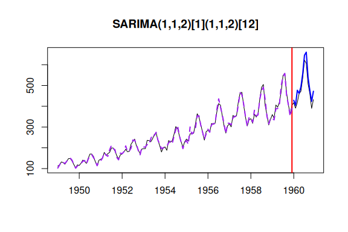

Second, if you want the model with intercept / drift, you can do it using `constant` parameter:

```r
testModel <- adam(AirPassengers, "NNN", silent=FALSE, lags=c(1,12), constant=TRUE,
                  orders=list(ar=c(1,1),i=c(1,1),ma=c(2,2)), distribution="dnorm",
                  h=12, holdout=TRUE)
testModel
```

```
#> Time elapsed: 0.09 seconds
#> Model estimated using adam() function: SARIMA(1,1,2)[1](1,1,2)[12] with drift
#> With backcasting initialisation
#> Distribution assumed in the model: Normal
#> Loss function type: likelihood; Loss function value: 483.6668
#> Intercept/Drift value: 1.5392
#> ARMA parameters of the model:
#>         Lag 1  Lag 12
#> AR(1) -0.5629 -0.9134
#>         Lag 1 Lag 12
#> MA(1)  0.2511 0.8799
#> MA(2) -0.0678 0.1041
#>
#> Sample size: 132
#> Number of estimated parameters: 34
#> Number of degrees of freedom: 98
#> Information criteria:
#>      AIC     AICc      BIC     BICc
#> 1035.333 1059.870 1133.349 1193.251
#>
#> Forecast errors:
#> ME: -12.771; MAE: 16.518; RMSE: 21.337
#> sCE: -58.384%; Asymmetry: -74.3%; sMAE: 6.293%; sMSE: 0.661%
#> MASE: 0.686; RMSSE: 0.681; rMAE: 0.217; rRMSE: 0.207
```

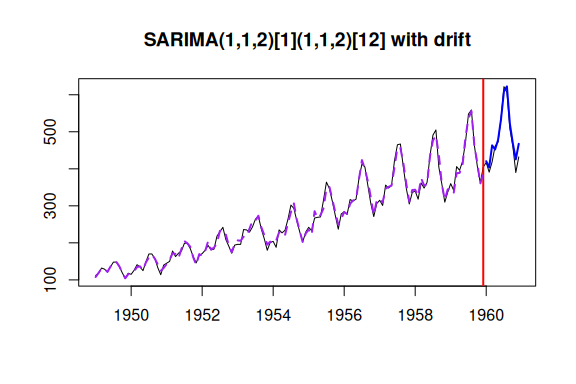

If the model contains non-zero differences, then the constant acts as a drift. Third, you can specify parameters of ARIMA via the `arma` parameter in the following manner:

```r
testModel <- adam(AirPassengers, "NNN", silent=FALSE, lags=c(1,12),
                  orders=list(ar=c(1,1),i=c(1,1),ma=c(2,2)), distribution="dnorm",
                  arma=list(ar=c(0.1,0.1), ma=c(-0.96, 0.03, -0.12, 0.03)),
                  h=12, holdout=TRUE)
testModel
```

```
#> Time elapsed: 0 seconds
#> Model estimated using adam() function: SARIMA(1,1,2)[1](1,1,2)[12]
#> With backcasting initialisation
#> Distribution assumed in the model: Normal
#> Loss function type: likelihood; Loss function value: 564.21
#> ARMA parameters of the model:
#>       Lag 1 Lag 12
#> AR(1)   0.1    0.1
#>       Lag 1 Lag 12
#> MA(1) -0.96  -0.12
#> MA(2)  0.03   0.03
#>
#> Sample size: 132
#> Number of estimated parameters: 27
#> Number of degrees of freedom: 105
#> Number of provided parameters: 6
#> Information criteria:
#>      AIC     AICc      BIC     BICc
#> 1182.420 1196.958 1260.256 1295.750
#>
#> Forecast errors:
#> ME: 9.579; MAE: 17.084; RMSE: 19.15
#> sCE: 43.789%; Asymmetry: 61.9%; sMAE: 6.508%; sMSE: 0.532%
#> MASE: 0.709; RMSSE: 0.611; rMAE: 0.225; rRMSE: 0.186
```

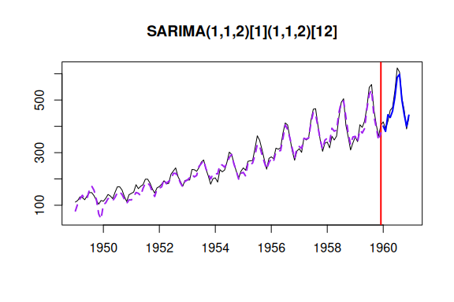

Finally, the initials for the states can also be provided, although getting the correct ones might be a challenging task (you also need to know how many of them to provide; checking `testModel$initial` might help):

```r
testModel <- adam(AirPassengers, "NNN", silent=FALSE, lags=c(1,12),
                  orders=list(ar=c(1,1),i=c(1,1),ma=c(2,0)), distribution="dnorm",
                  initial=list(arima=AirPassengers[1:24]),
                  h=12, holdout=TRUE)
testModel
```

```
#> Time elapsed: 0.05 seconds
#> Model estimated using adam() function: SARIMA(1,1,2)[1](1,1,0)[12]
#> With backcasting initialisation
#> Distribution assumed in the model: Normal
#> Loss function type: likelihood; Loss function value: 494.9289
#> ARMA parameters of the model:
#>         Lag 1  Lag 12
#> AR(1) -0.4837 -0.0502
#>        Lag 1
#> MA(1) 0.3488
#> MA(2) 0.0964
#>
#> Sample size: 132
#> Number of estimated parameters: 31
#> Number of degrees of freedom: 101
#> Information criteria:
#>      AIC     AICc      BIC     BICc
#> 1051.858 1071.698 1141.225 1189.662
#>
#> Forecast errors:
#> ME: -18.06; MAE: 19.481; RMSE: 24.594
#> sCE: -82.564%; Asymmetry: -91.9%; sMAE: 7.422%; sMSE: 0.878%
#> MASE: 0.809; RMSSE: 0.785; rMAE: 0.256; rRMSE: 0.239
```

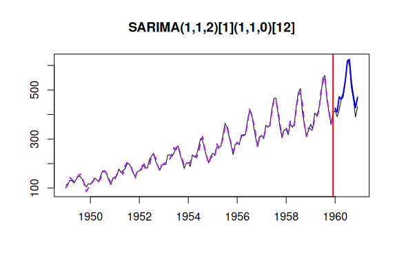

If you work with ADAM ARIMA model, then there is no such thing as “usual” bounds for the parameters, so the function will use the `bounds="admissible"`, checking the AR / MA polynomials in order to make sure that the model is stationary and invertible (aka stable).

Similarly to ETS, you can use different distributions and losses for the estimation. **Note that the order selection for ARIMA is done in `auto.adam()` function, not in the `adam()`!** However, if you do `orders=list(..., select=TRUE)` in `adam()`, it will call `auto.adam()` and do the selection.

Finally, ARIMA is typically slower than ETS, mainly because its initial states are more difficult to estimate due to an increased complexity of the model. If you want to speed things up, use `initial="backcasting"` and reduce the number of iterations via `maxeval` parameter.

# ADAM ETSX / ARIMAX / ETSX+ARIMA

Another important feature of ADAM is introduction of explanatory variables. Unlike in `es()`, `adam()` expects a matrix for `data` and can work with a formula. If the latter is not provided, then it will use all explanatory variables. Here is a brief example:

```r
BJData <- cbind(BJsales,BJsales.lead)
testModel <- adam(BJData, "AAN", h=18, silent=FALSE)
```

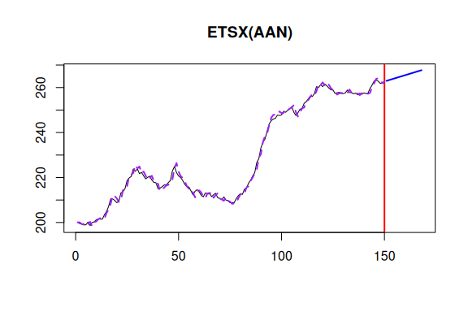

If you work with data.frame or similar structures, then you can use them directly, ADAM will extract the response variable either assuming that it is in the first column or from the provided formula (if you specify one via `formula` parameter). Here is an example, where we create a matrix with lags and leads of an explanatory variable:

```r
BJData <- cbind(as.data.frame(BJsales),as.data.frame(xregExpander(BJsales.lead,c(-7:7))))
colnames(BJData)[1] <- "y"
testModel <- adam(BJData, "ANN", h=18, silent=FALSE, holdout=TRUE, formula=y~xLag1+xLag2+xLag3)
testModel
```

```
#> Time elapsed: 0.11 seconds
#> Model estimated using adam() function: ETSX(ANN)
#> With backcasting initialisation
#> Distribution assumed in the model: Normal
#> Loss function type: likelihood; Loss function value: 197.1386
#> Persistence vector g (excluding xreg):
#> alpha
#>     1
#>
#> Sample size: 132
#> Number of estimated parameters: 6
#> Number of degrees of freedom: 126
#> Information criteria:
#>      AIC     AICc      BIC     BICc
#> 406.2772 406.9492 423.5740 425.2146
#>
#> Forecast errors:
#> ME: 1.182; MAE: 1.618; RMSE: 2.247
#> sCE: 9.413%; Asymmetry: 50.7%; sMAE: 0.716%; sMSE: 0.01%
#> MASE: 1.326; RMSSE: 1.438; rMAE: 0.723; rRMSE: 0.896
```

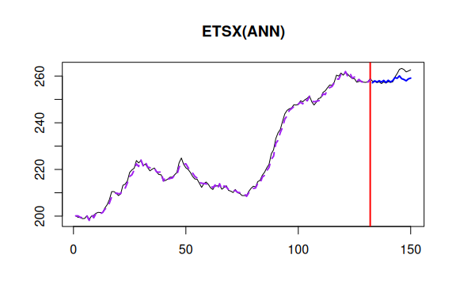

Similarly to `es()`, there is a support for variables selection, but via the `regressors` parameter instead of `xregDo`, which will then use `stepwise()` function from `greybox` package on the residuals of the model:

```r
testModel <- adam(BJData, "ANN", h=18, silent=FALSE, holdout=TRUE, regressors="select")
```

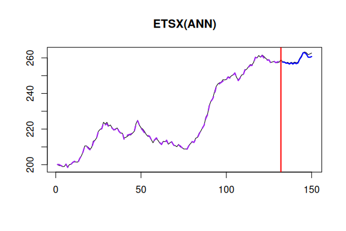

The same functionality is supported with ARIMA, so you can have, for example, ARIMAX(0,1,1), which is equivalent to ETSX(A,N,N):

```r
testModel <- adam(BJData, "NNN", h=18, silent=FALSE, holdout=TRUE, regressors="select", orders=c(0,1,1))
```

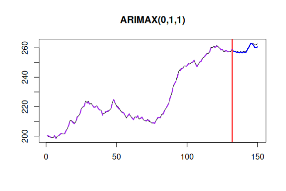

The two models might differ because they have different initialisation in the optimiser and different bounds for parameters (ARIMA relies on invertibility condition, while ETS does the usual (0,1) bounds by default). It is possible to make them identical if the number of iterations is increased and the initial parameters are the same. Here is an example of what happens, when the two models have exactly the same parameters:

```r
BJData <- BJData[,c("y",names(testModel$initial$xreg))];
testModel <- adam(BJData, "NNN", h=18, silent=TRUE, holdout=TRUE, orders=c(0,1,1),
                  initial=testModel$initial, arma=testModel$arma)
testModel
```

```
#> Time elapsed: 0 seconds
#> Model estimated using adam() function: ARIMAX(0,1,1)
#> With provided initialisation
#> Distribution assumed in the model: Normal
#> Loss function type: likelihood; Loss function value: 618.2048
#> ARMA parameters of the model:
#>        Lag 1
#> MA(1) 0.2402
#>
#> Sample size: 132
#> Number of estimated parameters: 1
#> Number of degrees of freedom: 131
#> Number of provided parameters: 7
#> Information criteria:
#>      AIC     AICc      BIC     BICc
#> 1238.410 1238.440 1241.292 1241.368
#>
#> Forecast errors:
#> ME: 0.636; MAE: 0.636; RMSE: 0.872
#> sCE: 5.063%; Asymmetry: 100%; sMAE: 0.281%; sMSE: 0.001%
#> MASE: 0.521; RMSSE: 0.558; rMAE: 0.284; rRMSE: 0.347
```

```r
names(testModel$initial)[1] <- names(testModel$initial)[[1]] <- "level"
testModel2 <- adam(BJData, "ANN", h=18, silent=TRUE, holdout=TRUE,
                   initial=testModel$initial, persistence=testModel$arma$ma+1)
testModel2
```

```
#> Time elapsed: 0 seconds
#> Model estimated using adam() function: ETSX(ANN)
#> With provided initialisation
#> Distribution assumed in the model: Normal
#> Loss function type: likelihood; Loss function value: 539.0386
#> Persistence vector g (excluding xreg):
#>  alpha
#> 1.2402
#>
#> Sample size: 132
#> Number of estimated parameters: 1
#> Number of degrees of freedom: 131
#> Number of provided parameters: 7
#> Information criteria:
#>      AIC     AICc      BIC     BICc
#> 1080.077 1080.108 1082.960 1083.035
#>
#> Forecast errors:
#> ME: 0.636; MAE: 0.636; RMSE: 0.872
#> sCE: 5.063%; Asymmetry: 100%; sMAE: 0.281%; sMSE: 0.001%
#> MASE: 0.521; RMSSE: 0.558; rMAE: 0.284; rRMSE: 0.347
```

Another feature of ADAM is the time varying parameters in the SSOE framework, which can be switched on via `regressors="adapt"`:

```r
testModel <- adam(BJData, "ANN", h=18, silent=FALSE, holdout=TRUE, regressors="adapt")
testModel$persistence
```

```
#>     alpha    delta1    delta2    delta3    delta4    delta5
#> 0.4868570 0.1609712 0.1191716 0.1594353 0.2062682 0.1044465
```

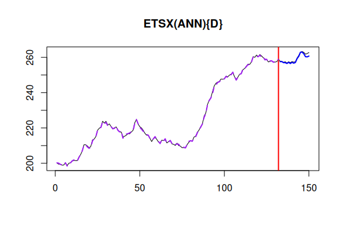

Note that the default number of iterations might not be sufficient in order to get close to the optimum of the function, so setting `maxeval` to something bigger might help. If you want to explore, why the optimisation stopped, you can provide `print_level=41` parameter to the function, and it will print out the report from the optimiser. In the end, the default parameters are tuned in order to give a reasonable solution, but given the complexity of the model, they might not guarantee to give the best one all the time.

Finally, you can produce a mixture of ETS, ARIMA and regression, by using the respective parameters, like this:

```r
testModel <- adam(BJData, "AAN", h=18, silent=FALSE, holdout=TRUE, orders=c(1,0,0))
summary(testModel)
```

```
#>
#> Model estimated using adam() function: ETSX(AAN)+ARIMA(1,0,0)
#> Response variable: y
#> Distribution used in the estimation: Normal
#> Loss function type: likelihood; Loss function value: 55.8706
#> Coefficients:
#>         Estimate Std. Error Lower 2.5% Upper 97.5%
#> alpha     0.1520     0.1411     0.0000      0.4309
#> beta      0.1520     0.3239     0.0000      0.1520
#> phi1[1]   0.9847     0.1354     0.7167      1.2523 *
#> xLag3     4.7035     7.8578   -10.8545     20.2351
#> xLag7     0.5168     7.8741   -15.0733     16.0805
#> xLag4     3.3823     7.3060   -11.0830     17.8231
#> xLag6     1.4001     7.3028   -13.0590     15.8347
#> xLag5     2.1980     6.5362   -10.7433     15.1173
#>
#> Error standard deviation: 0.3859
#> Sample size: 132
#> Number of estimated parameters: 12
#> Number of degrees of freedom: 120
#> Information criteria:
#>      AIC     AICc      BIC     BICc
#> 135.7411 138.3630 170.3348 176.7358
```

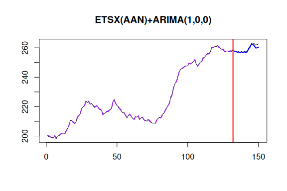

This might be handy, when you explore a high frequency data, want to add calendar events, apply ETS and add AR/MA errors to it.

Finally, if you estimate ETSX or ARIMAX model and want to speed things up, it is recommended to use `initial="backcasting"`, which will then initialise dynamic part of the model via backcasting and use optimisation for the parameters of the explanatory variables:

```r
testModel <- adam(BJData, "AAN", h=18, silent=TRUE, holdout=TRUE, initial="backcasting")
summary(testModel)
```

```
#>
#> Model estimated using adam() function: ETSX(AAN)
#> Response variable: y
#> Distribution used in the estimation: Normal
#> Loss function type: likelihood; Loss function value: 46.091
#> Coefficients:
#>       Estimate Std. Error Lower 2.5% Upper 97.5%
#> alpha   0.7513     0.0918     0.5695      0.9328 *
#> beta    0.5038     0.2949     0.0000      0.7513
#> xLag3   4.5727     2.3827    -0.1441      9.2829
#> xLag7   0.4112     2.3897    -4.3194      5.1352
#> xLag4   3.1462     2.1168    -1.0443      7.3308
#> xLag6   1.0647     2.1153    -3.1227      5.2463
#> xLag5   1.8214     2.0149    -2.1673      5.8044
#>
#> Error standard deviation: 0.3554
#> Sample size: 132
#> Number of estimated parameters: 10
#> Number of degrees of freedom: 122
#> Information criteria:
#>      AIC     AICc      BIC     BICc
#> 112.1821 114.0003 141.0101 145.4490
```

# Auto ADAM

While the original `adam()` function allows selecting ETS components and explanatory variables, it does not allow selecting the most suitable distribution and / or ARIMA components. This is what `auto.adam()` function is for.

In order to do the selection of the most appropriate distribution, you need to provide a vector of those that you want to check:

```r
testModel <- auto.adam(BJsales, "XXX", silent=FALSE,
                       distribution=c("dnorm","dlaplace","ds"),
                       h=12, holdout=TRUE)
```

```
#> Evaluating models with different distributions... dnorm ,  Selecting ARIMA orders...
#> Selecting differences...
#> Selecting ARMA... |
#> The best ARIMA is selected. dlaplace ,  Selecting ARIMA orders...
#> Selecting differences...
#> Selecting ARMA... |
#> The best ARIMA is selected. ds ,  Selecting ARIMA orders...
#> Selecting differences...
#> Selecting ARMA... |-
#> The best ARIMA is selected. Done!
```

```r
testModel
```

```
#> Time elapsed: 0.41 seconds
#> Model estimated using auto.adam() function: ETS(AAdN)
#> With backcasting initialisation
#> Distribution assumed in the model: Normal
#> Loss function type: likelihood; Loss function value: 237.6128
#> Persistence vector g:
#>  alpha   beta
#> 0.9448 0.2979
#> Damping parameter: 0.8789
#> Sample size: 138
#> Number of estimated parameters: 6
#> Number of degrees of freedom: 132
#> Information criteria:
#>      AIC     AICc      BIC     BICc
#> 487.2257 487.8669 504.7892 506.3689
#>
#> Forecast errors:
#> ME: 2.817; MAE: 2.967; RMSE: 3.654
#> sCE: 14.869%; Asymmetry: 88%; sMAE: 1.305%; sMSE: 0.026%
#> MASE: 2.491; RMSSE: 2.382; rMAE: 0.957; rRMSE: 0.954
```

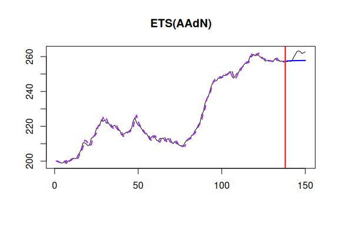

This process can also be done in parallel on either the automatically selected number of cores (e.g. `parallel=TRUE`) or on the specified by user (e.g. `parallel=4`):

```r
testModel <- auto.adam(BJsales, "ZZZ", silent=FALSE, parallel=TRUE,
                       h=12, holdout=TRUE)
```

If you want to add ARIMA or regression components, you can do it in the exactly the same way as for the `adam()` function. Here is an example of ETS+ARIMA:

```r
testModel <- auto.adam(BJsales, "AAN", orders=list(ar=2,i=0,ma=0), silent=TRUE,
                       distribution=c("dnorm","dlaplace","ds","dgnorm"),
                       h=12, holdout=TRUE)
testModel
```

```
#> Time elapsed: 0.18 seconds
#> Model estimated using auto.adam() function: ETS(AAN)+ARIMA(2,0,0)
#> With backcasting initialisation
#> Distribution assumed in the model: Normal
#> Loss function type: likelihood; Loss function value: 240.7793
#> Persistence vector g:
#>  alpha   beta
#> 0.3478 0.1734
#>
#> ARMA parameters of the model:
#>        Lag 1
#> AR(1) 0.7154
#> AR(2) 0.2846
#>
#> Sample size: 138
#> Number of estimated parameters: 9
#> Number of degrees of freedom: 129
#> Information criteria:
#>      AIC     AICc      BIC     BICc
#> 499.5587 500.9649 525.9040 529.3684
#>
#> Forecast errors:
#> ME: 2.973; MAE: 3.098; RMSE: 3.832
#> sCE: 15.694%; Asymmetry: 89.9%; sMAE: 1.363%; sMSE: 0.028%
#> MASE: 2.6; RMSSE: 2.498; rMAE: 0.999; rRMSE: 1
```

```r
testModel <- auto.adam(BJsales, "XXN", orders=list(ar=2,i=2,ma=2,select=TRUE),
                       distribution="default", silent=FALSE,
                       h=12, holdout=TRUE)
```

```
#> Evaluating models with different distributions... default ,  Selecting ARIMA orders...
#> Selecting differences...
#> Selecting ARMA... |
#> The best ARIMA is selected. Done!
```

```r
testModel
```

```
#> Time elapsed: 0.12 seconds
#> Model estimated using auto.adam() function: ETS(AAdN)
#> With backcasting initialisation
#> Distribution assumed in the model: Normal
#> Loss function type: likelihood; Loss function value: 237.6128
#> Persistence vector g:
#>  alpha   beta
#> 0.9448 0.2979
#> Damping parameter: 0.8789
#> Sample size: 138
#> Number of estimated parameters: 6
#> Number of degrees of freedom: 132
#> Information criteria:
#>      AIC     AICc      BIC     BICc
#> 487.2257 487.8669 504.7892 506.3689
#>
#> Forecast errors:
#> ME: 2.817; MAE: 2.967; RMSE: 3.654
#> sCE: 14.869%; Asymmetry: 88%; sMAE: 1.305%; sMSE: 0.026%
#> MASE: 2.491; RMSSE: 2.382; rMAE: 0.957; rRMSE: 0.954
```

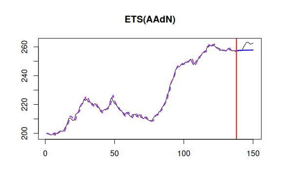

Knowing how to work with `adam()`, you can use similar principles, when dealing with `auto.adam()`. Just keep in mind that the provided `persistence`, `phi`, `initial`, `arma` and `B` won’t work, because this contradicts the idea of the model selection.

Finally, there is also the mechanism of automatic outliers detection, which extracts residuals from the best model, flags observations that lie outside the prediction interval of the width `level` in sample and then refits `auto.adam()` with the dummy variables for the outliers. Here how it works:

```r
testModel <- auto.adam(AirPassengers, "PPP", silent=FALSE, outliers="use",
                       distribution="default",
                       h=12, holdout=TRUE)
```

```
#> Evaluating models with different distributions... default ,  Selecting ARIMA orders...
#> Selecting differences...
#> Selecting ARMA... |-
#> The best ARIMA is selected.
#> Dealing with outliers...
```

```r
testModel
```

```
#> Time elapsed: 2.02 seconds
#> Model estimated using auto.adam() function: ETSX(MMM)
#> With backcasting initialisation
#> Distribution assumed in the model: Gamma
#> Loss function type: likelihood; Loss function value: 464.8552
#> Persistence vector g (excluding xreg):
#>  alpha   beta  gamma
#> 0.7618 0.0000 0.0000
#>
#> Sample size: 132
#> Number of estimated parameters: 18
#> Number of degrees of freedom: 114
#> Information criteria:
#>       AIC      AICc       BIC      BICc
#>  965.7104  971.7635 1017.6008 1032.3788
#>
#> Forecast errors:
#> ME: -9.845; MAE: 15.551; RMSE: 22.996
#> sCE: -45.008%; Asymmetry: -61.9%; sMAE: 5.924%; sMSE: 0.767%
#> MASE: 0.646; RMSSE: 0.734; rMAE: 0.205; rRMSE: 0.223
```

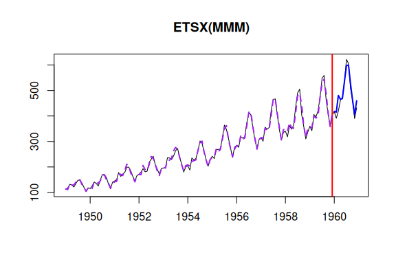

If you specify `outliers="select"`, the function will create leads and lags 1 of the outliers and then select the most appropriate ones via the `regressors` parameter of adam.

If you want to know more about ADAM, you are welcome to visit [the online monograph](https://www.openforecast.org/adam/).

Hyndman, Rob J, Anne B Koehler, J Keith Ord, and Ralph D Snyder. 2008. *Forecasting with Exponential Smoothing*. Springer Berlin Heidelberg.